# PSICOLOGIA: Investigación y Estadística II

- Profesor: [Dr. José Manuel Magallanes, Ph.D.](http://www.pucp.edu.pe/profesor/jose-manuel-magallanes/)
  - Profesor del Departamento de Ciencias Sociales, Sección de Ciencia Política y Gobierno. Profesor Afiliado del Departamento de Psicología.
  - [Oficina 105](https://goo.gl/maps/xuGeG6o9di1i1y5m6) - Edificio CISEPA / ECONOMIA / CCSS
  - Telefono: (51) 1 - 6262000 anexo 4302
  - Correo Electrónico: jmagallanes@pucp.edu.pe

## Cambiando atributos de las variables

### 1. Carga de archivos

Los archivos deben estar siempre en la nube, si es en SPSS se puede usar GitHub para almacenarlos, si es en CSV, en GoogleSheets. En particular, usaras SPSS si alguien comparte ese tipo de archivo contigo; pero si recoges tu propia información, será mejor que te familiarices con CSV en Google.

El archivo **hsb.sav** puedes descargarlo desde [aqui](https://github.com/PsicologiaPUCP/ArchivosDeDatos/raw/master/hsb.sav), y si lo abres en SPSS verás, en la vista de datos (Data View) esto:

[figure not shown]

Lo que ves es los datos en SPSS pero **no sabes si los tipos de datos** han sido bien identificados. La buena identificación de los tipos de datos es clave para saber bien qué técnicas elegir. En este momento, SPSS ha identificado los datos así el vista de variables (metadata):

[figure not shown]

SPSS puede manejar esta información pues tiene la vista de datos y la vista de metadata. Por ejemplo, Excel no tiene metadata:

[figure not shown]

Si subes tu archivo en Excel a GoogleSheets y lo conviertes a formato CSV, puedes publicarlo siguiendo estas [instrucciones](https://www.youtube.com/watch?time_continue=159&v=jxKmnhbrUWs). El link en formato CSV puedes leerlo en R y de ahí darle tratamiento para llevarlo a SPSS:

```r
# link a data:
linkCSV="https://docs.google.com/spreadsheets/d/e/2PACX-1vTcFY_f_k94wuMUL8ISrklSmjlbYgnPeEVdGApFI0Y39OQB8IrHvv1bmD6E0u9uYo06Bpl5llns-BLR/pub?gid=1282421390&single=true&output=csv"

# recuperar data:
hsbCSV=read.csv(linkCSV,stringsAsFactors = F)
```

Esta sería la vista de datos (resumida):

```r
# ver lo que se recuperó:
head(hsbCSV)
```

```
##   ID SEX RACE SES SCTYP HSP LOCUS CONCPT  MOT CAR  RDG WRTG MATH  SCI  CIV
## 1  1   2    2   1     1   3  0.29   0.88 0.67  10 33.6 43.7 40.2 39.0 40.6
## 2  2   1    2   1     1   2 -0.42   0.03 0.33   2 46.9 35.9 41.9 36.3 45.6
## 3  3   2    2   1     1   2  0.71   0.03 0.67   9 41.6 59.3 41.9 44.4 45.6
## 4  4   2    2   2     1   3  0.06   0.03 0.00  15 38.9 41.1 32.7 41.7 40.6
## 5  5   2    2   2     1   3  0.22  -0.28 0.00   1 36.3 48.9 39.5 41.7 45.6
## 6  6   1    2   2     1   2  0.46   0.03 0.00  11 49.5 46.3 46.2 41.7 35.6
```

Y esta sería la metadata:

```r
# ver lo que se recuperó:
str(hsbCSV)
```

```
## 'data.frame':    600 obs. of  15 variables:
##  $ ID    : int  1 2 3 4 5 6 7 8 9 10 ...
##  $ SEX   : int  2 1 2 2 2 1 1 2 1 2 ...
##  $ RACE  : int  2 2 2 2 2 2 2 2 2 2 ...
##  $ SES   : int  1 1 1 2 2 2 1 1 2 1 ...
##  $ SCTYP : int  1 1 1 1 1 1 1 1 1 1 ...
##  $ HSP   : int  3 2 2 3 3 2 1 1 1 1 ...
##  $ LOCUS : num  0.29 -0.42 0.71 0.06 0.22 0.46 0.44 0.68 0.06 0.05 ...
##  $ CONCPT: num  0.88 0.03 0.03 0.03 -0.28 0.03 -0.47 0.25 0.56 0.15 ...
##  $ MOT   : num  0.67 0.33 0.67 0 0 0 0.33 1 0.33 1 ...
##  $ CAR   : int  10 2 9 15 1 11 10 9 9 11 ...
##  $ RDG   : num  33.6 46.9 41.6 38.9 36.3 49.5 62.7 44.2 46.9 44.2 ...
##  $ WRTG  : num  43.7 35.9 59.3 41.1 48.9 46.3 64.5 51.5 41.1 49.5 ...
##  $ MATH  : num  40.2 41.9 41.9 32.7 39.5 46.2 48 36.9 45.3 40.5 ...
##  $ SCI   : num  39 36.3 44.4 41.7 41.7 41.7 63.4 49.8 47.1 39 ...
##  $ CIV   : num  40.6 45.6 45.6 40.6 45.6 35.6 55.6 55.6 55.6 50.6 ...
```

### 2. Identificar atributos

Toda variable tiene:

- Nombre
- Descripción
- Escala
  - Texto
  - Categórica
    - Nominal
    - Ordinal
  - Numérica

Si la variable es *Categórica*, tiene **niveles**.

Esta información debe buscarse en el diccionario de datos o las guías metodológicas de la data. Para el caso de la data que acabamos de abrir, el documento está [aquí](https://github.com/PsicologiaPUCP/ArchivosDeDatos/raw/master/metadata/hsb.pdf). Las variables deben tener esta información; y eso es lo que haremos a continuación.

### 3. Reajustar tipo de datos

Leyendo la guia de datos sabrás como ajustar cada variable. En SPSS, debes ir al menú *Datos* y de ahí elegir *Definir Propiedades de Variables*:

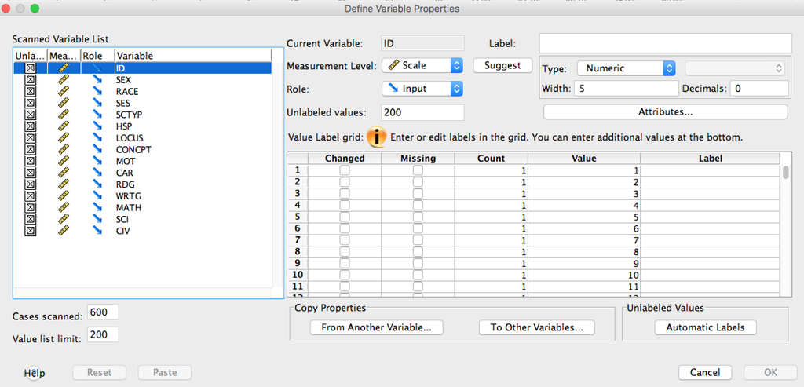

Ahi vas llenando los valores que corresponden. Recuerda grabar lo ingresado a sintaxis de SPSS.

Si revisas la sintaxis de SPSS, esto ha pasado:

1. Ajuste de la variable clave y la ordinal:

[figure not shown]

2. Ajuste de las variables Nominales:

[figure not shown]

3. Ajuste de las variables numéricas:

[figure not shown]

Al final, tu metadata debe ser:

[figure not shown]

La sintaxis de SPSS la puedes descargar de [aquí](https://github.com/PsicologiaPUCP/ArchivosDeDatos/raw/master/hsb_atributos.sps).

Estos ajuste no se puede hacer en Excel (ni en Google Sheets). Las hojas de calculo no hacen en general ninguna operación aritmética ni algebraica sobre texto.

Siguiendo las especificaciones de la metadata, vemos que R ha identificado bien todas las numéricas, desde LOCUS a CIV. R y SPSS identifican siempre los valores con decimales como números, salvo que algún valor está mal escrito en esa columna (sea un texto)

Para convertir en R, puedes hacer esto:

- El campo clave hacia character:

```r
hsbCSV$ID=as.character(hsbCSV$ID)
```

- La columna ordinal a “factor” ordinal:

Ajustemos la única ordinal que hay, nivel socio económico. Sigue estos pasos:

1. Explorar:

```r
table(hsbCSV$SES)
```

```
##
##   1   2   3
## 139 299 162
```

2. Ajustar:

```r
hsbCSV$SES=factor(hsbCSV$SES,     #variable
                  levels=c(1,2,3),#orden
                  labels = c("Low","Medium","High"), #sigue orden de 'levels'
                  ordered = TRUE) # para ordinal

# verificando:
table(hsbCSV$SES)
```

```
##
##    Low Medium   High
##    139    299    162
```

- Las columnas nominales:

Las nominales se convierten así:

```r
# etiquetas
varsLabels=list(SEX=c('Male','Female'),
                RACE=c('Hispanic','Asian','Black','White'),
                SCTYP=c('Public','Private'),
                HSP=c('General','Academic preparatory','Vocational/technical'),
                CAR=c('Clerical','Craftsman','Farmer','Homemaker','Laborer','Manager',
                  'Military','Operative','Professional 1','Professional 2','Proprietor',
                  'Protective','Sales','School','Service','Technical','Not working'))

# cambios
hsbCSV$SEX=factor(hsbCSV$SEX,
                  levels = 1:length(varsLabels$SEX),
                  labels=varsLabels$SEX)

hsbCSV$RACE=factor(hsbCSV$RACE,
                  levels = 1:length(varsLabels$RACE),
                  labels=varsLabels$RACE)

hsbCSV$SCTYP=factor(hsbCSV$SCTYP,
                  levels = 1:length(varsLabels$SCTYP),
                  labels=varsLabels$SCTYP)

hsbCSV$HSP=factor(hsbCSV$HSP,
                  levels = 1:length(varsLabels$HSP),
                  labels=varsLabels$HSP)

hsbCSV$CAR=factor(hsbCSV$CAR,
                  levels = 1:length(varsLabels$CAR),
                  labels=varsLabels$CAR)
```

La metadata de R se debe haber modificado.

```r
str(hsbCSV)
```

```
## 'data.frame':    600 obs. of  15 variables:
##  $ ID    : chr  "1" "2" "3" "4" ...
##  $ SEX   : Factor w/ 2 levels "Male","Female": 2 1 2 2 2 1 1 2 1 2 ...
##  $ RACE  : Factor w/ 4 levels "Hispanic","Asian",..: 2 2 2 2 2 2 2 2 2 2 ...
##  $ SES   : Ord.factor w/ 3 levels "Low"<"Medium"<..: 1 1 1 2 2 2 1 1 2 1 ...
##  $ SCTYP : Factor w/ 2 levels "Public","Private": 1 1 1 1 1 1 1 1 1 1 ...
##  $ HSP   : Factor w/ 3 levels "General","Academic preparatory",..: 3 2 2 3 3 2 1 1 1 1 ...
##  $ LOCUS : num  0.29 -0.42 0.71 0.06 0.22 0.46 0.44 0.68 0.06 0.05 ...
##  $ CONCPT: num  0.88 0.03 0.03 0.03 -0.28 0.03 -0.47 0.25 0.56 0.15 ...
##  $ MOT   : num  0.67 0.33 0.67 0 0 0 0.33 1 0.33 1 ...
##  $ CAR   : Factor w/ 17 levels "Clerical","Craftsman",..: 10 2 9 15 1 11 10 9 9 11 ...
##  $ RDG   : num  33.6 46.9 41.6 38.9 36.3 49.5 62.7 44.2 46.9 44.2 ...
##  $ WRTG  : num  43.7 35.9 59.3 41.1 48.9 46.3 64.5 51.5 41.1 49.5 ...
##  $ MATH  : num  40.2 41.9 41.9 32.7 39.5 46.2 48 36.9 45.3 40.5 ...
##  $ SCI   : num  39 36.3 44.4 41.7 41.7 41.7 63.4 49.8 47.1 39 ...
##  $ CIV   : num  40.6 45.6 45.6 40.6 45.6 35.6 55.6 55.6 55.6 50.6 ...
```

### 4. Pedir Descriptivos

Cuando tengas ya los datos ajustados, puedes ya solicitar los estadísticos descriptivos.

Si a SPSS le pides descriptivos con este código:

[figure not shown]

Obtienes esto:

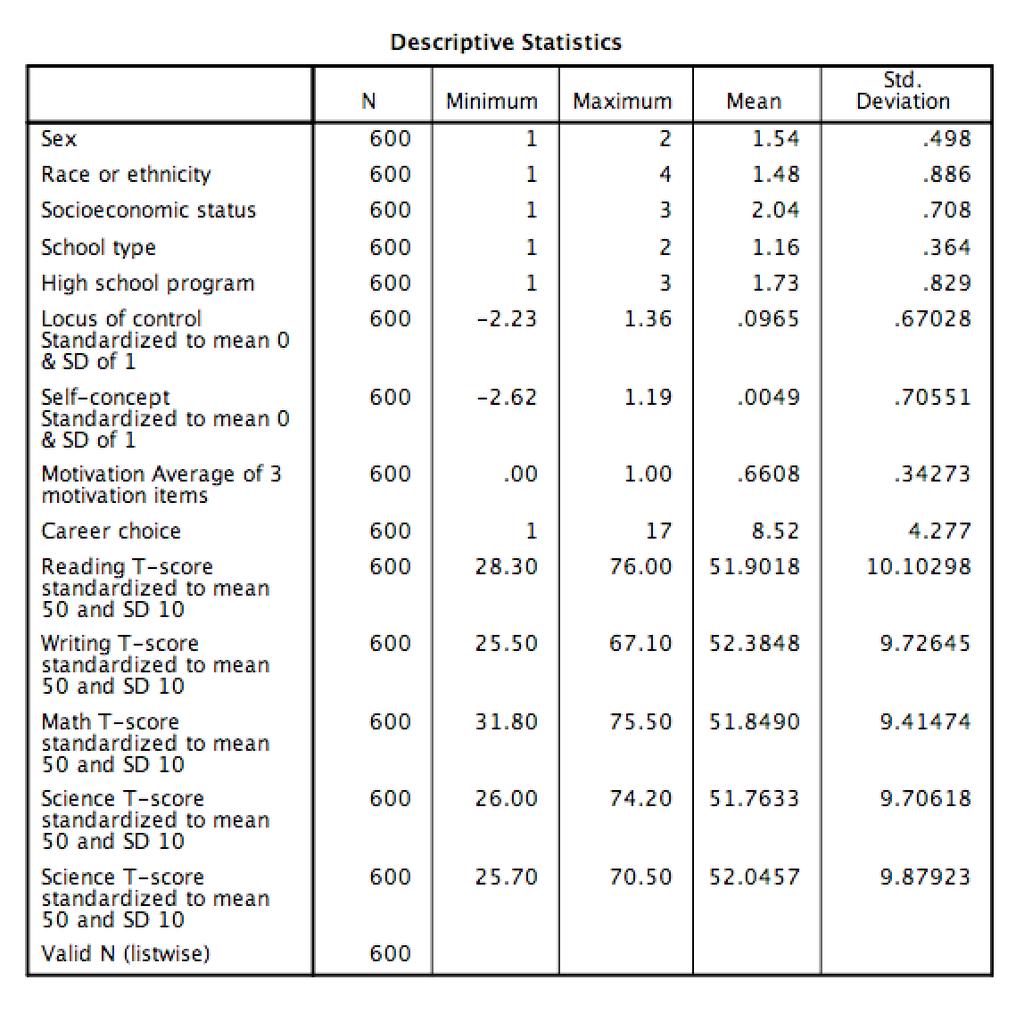

Lo que debiste hacer, es usar el comando frecuencias para las categóricas:

[figure not shown]

Y ahí si obtienes esto:

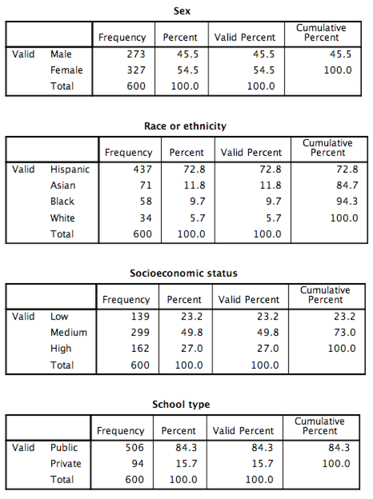

En Excel no pudes pedir descriptivos a las categoricas, salvo que estén representadas por números. Por otro lado, si al R le pides descriptivos si obtienes diferencias:

```r
summary(hsbCSV)
```

```
##       ID                SEX            RACE         SES          SCTYP
##  Length:600         Male  :273   Hispanic:437   Low   :139   Public :506
##  Class :character   Female:327   Asian   : 71   Medium:299   Private: 94
##  Mode  :character                Black   : 58   High  :162
##                                  White   : 34
##
##
##
##                    HSP          LOCUS              CONCPT
##  General             :308   Min.   :-2.23000   Min.   :-2.620000
##  Academic preparatory:145   1st Qu.:-0.37250   1st Qu.:-0.300000
##  Vocational/technical:147   Median : 0.21000   Median : 0.030000
##                             Mean   : 0.09653   Mean   : 0.004917
##                             3rd Qu.: 0.51000   3rd Qu.: 0.440000
##                             Max.   : 1.36000   Max.   : 1.190000
##
##       MOT                     CAR           RDG            WRTG
##  Min.   :0.0000   Professional 1:161   Min.   :28.3   Min.   :25.50
##  1st Qu.:0.3300   Professional 2: 94   1st Qu.:44.2   1st Qu.:44.30
##  Median :0.6700   Clerical      : 50   Median :52.1   Median :54.10
##  Mean   :0.6608   Craftsman     : 39   Mean   :51.9   Mean   :52.38
##  3rd Qu.:1.0000   Technical     : 36   3rd Qu.:60.1   3rd Qu.:59.90
##  Max.   :1.0000   Homemaker     : 33   Max.   :76.0   Max.   :67.10
##                   (Other)       :187
##       MATH            SCI             CIV
##  Min.   :31.80   Min.   :26.00   Min.   :25.70
##  1st Qu.:44.50   1st Qu.:44.40   1st Qu.:45.60
##  Median :51.30   Median :52.60   Median :50.60
##  Mean   :51.85   Mean   :51.76   Mean   :52.05
##  3rd Qu.:58.38   3rd Qu.:58.65   3rd Qu.:60.50
##  Max.   :75.50   Max.   :74.20   Max.   :70.50
##
```